# FigureYa241scRNA_NMI

Jianing Gao

2025-5-20

# 需求描述 / Requirement Description

求用R实现图1E或者文章中别的Transcriptional homogeneity (NMI)图 / Please help implement Figure 1E or other Transcriptional homogeneity (NMI) plots from the paper using R.

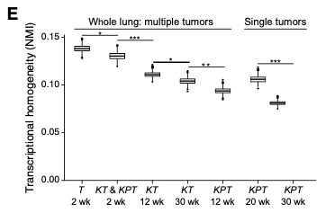

出自https://linkinghub.elsevier.com/retrieve/pii/S1535610820303160

Figure1. Increased Transcriptional Heterogeneity in Mouse LUAD Evolution Is Reproducible across Individual Tumors and Mice, but Cannot Fully Be Explained by Gene Copy Number Variation

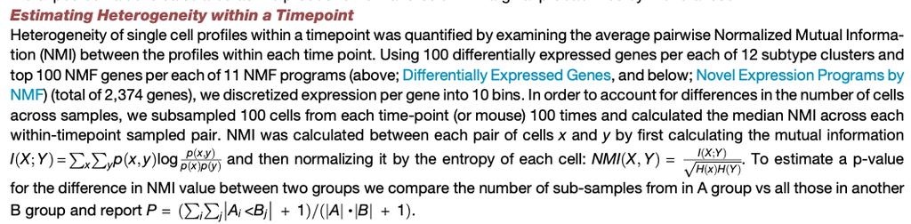

# 应用场景 / Application Scenario

利用单细胞数据评估同一(时间点)肿瘤样本的转录异质性 / Using single-cell data to evaluate transcriptional heterogeneity of tumor samples at the same (time point)

问题描述：同一个样本有若干个细胞，注意我们测的转录组是单细胞水平的，但是要评估是样本的转录组异质性。因此一个简单的想法是： / Problem description: The same sample has several cells. Note that we measure transcriptomes at the single-cell level, but we need to evaluate the transcriptional heterogeneity of the sample. Therefore, a simple idea is:

- a)如果一个样本中的所有细胞，其距离的方差越大，则样本转录组异质性越高。据此，任何和方差关联的指标，其实都可以用来评估样本的转录组异质性。当然还有其它的指标，比如， / a) If the variance of distances between all cells in a sample is larger, then the transcriptional heterogeneity of the sample is higher. Based on this, any metrics associated with variance can be used to evaluate the transcriptional heterogeneity of samples. Of course, there are other indicators, such as,
- b)我们可以评估样本内的cluster的多样性，同一样本的cluster越多样，该样本转录异质性越高，这个多样性可以用信息熵来计算。 / b) We can evaluate the diversity of clusters within a sample. The more diverse the clusters in the same sample, the higher the transcriptional heterogeneity of that sample. This diversity can be calculated using information entropy.
- 本文作者则采取了互信息(可以理解为两个细胞转录组的相似性)来评估。对每一个样本的细胞进行不放回抽样(100 cells)，然后利用normalized mutual information (NMI)来衡量每对细胞之间的相似性。作者对每个样本进行100次抽样，每次抽样的NMI的中值作为该样本在此次抽样下的transcriptional homogeneity(转录同质性)。最后，作者采用了经验P值来进行显著性分析。 / The authors of this paper used mutual information (which can be understood as the similarity between two cell transcriptomes) for evaluation. They performed sampling without replacement (100 cells) for cells from each sample, then used normalized mutual information (NMI) to measure the similarity between each pair of cells. The authors performed 100 samplings for each sample, using the median NMI of each sampling as the transcriptional homogeneity of that sample under this sampling. Finally, the authors used empirical P-values for significance analysis.

例文的Figure 2D和G，利用cNMF提取expression programs，并通过整合其它已发表的数据，利用Gene set analysis来推断expression programs的生物学意义。做法可参考FigureYa226scRNA_cNMF / Figures 2D and G in the example paper use cNMF to extract expression programs, and through integration with other published data, use Gene set analysis to infer the biological significance of expression programs. The method can be referenced from FigureYa226scRNA_cNMFhttps://k.koudai.com/T9Zd8Fu9

# 环境设置 / Environment Setup

使用国内镜像安装包 / Use domestic mirrors to install packages

```r
options("repos"= c(CRAN="https://mirrors.tuna.tsinghua.edu.cn/CRAN/"))
options(BioC_mirror="http://mirrors.tuna.tsinghua.edu.cn/bioconductor/")
```

加载包

```r
library(Seurat)
library(rhdf5)
library(tidyverse)
Sys.setenv(LANGUAGE = "en") #显示英文报错信息 Display English error message
options(stringsAsFactors = FALSE) #禁止chr转成factor Disable conversion of chr to factor
```

# 0. 导入数据 / Import Data

输入数据的微云链接 / Input data WeiyunLink: https://share.weiyun.com/GqYbpeGV

## 0.1 cell meta信息 / Cell Meta Information

```r
genes <- read.csv("data/GSE154989_mmLungPlate_fQC_geneTable.csv")
cells <- read.csv("data/GSE154989_mmLungPlate_fQC_smpTable.csv")
head(genes)
```

```
##                        geneID                ensgID geneSymbol  length
## 1  ENSMUSG00000000001.4_Gnai3  ENSMUSG00000000001.4      Gnai3 3262.00
## 2  ENSMUSG00000000003.15_Pbsn ENSMUSG00000000003.15       Pbsn  799.50
## 3 ENSMUSG00000000028.14_Cdc45 ENSMUSG00000000028.14      Cdc45 1574.00
## 4   ENSMUSG00000000031.15_H19 ENSMUSG00000000031.15        H19 1268.60
## 5 ENSMUSG00000000037.16_Scml2 ENSMUSG00000000037.16      Scml2 3297.14
## 6  ENSMUSG00000000049.11_Apoh ENSMUSG00000000049.11       Apoh  665.50
```

```r
head(cells)
```

```
##                  sampleID            plateID         mouseID        timesimple
## 1 KP_30w_ND_m3_T7_P1_S302 KP_30w_ND_m3_T7_P1 KP_30w_ND_m3_T7      08_KP_30w_ND
## 2 KP_30w_ND_m2_T4_P5_S331 KP_30w_ND_m2_T4_P5 KP_30w_ND_m2_T4      08_KP_30w_ND
## 3  K_12w_ND_m3_T0_P2_S272  K_12w_ND_m3_T0_P2     K_12w_ND_m3       04_K_12w_ND
## 4 KP_30w_ND_m2_T1_P4_S219 KP_30w_ND_m2_T1_P4 KP_30w_ND_m2_T1      08_KP_30w_ND
## 5   K_2w_ND_m3_T0_P1_S245   K_2w_ND_m3_T0_P1      K_2w_ND_m3 02_KorKP_early_ND
## 6 KP_30w_ND_m1_T2_P1_S267 KP_30w_ND_m1_T2_P1 KP_30w_ND_m1_T2      08_KP_30w_ND
##         typeID
## 1 08_KP_30w_ND
## 2 08_KP_30w_ND
## 3  04_K_12w_ND
## 4 08_KP_30w_ND
## 5   02_K_2w_ND
## 6 08_KP_30w_ND
```

```r
duplicated(genes$ensgID) %>% table
```

```
## .
## FALSE
## 52638
```

```r
cells.annot <- read.csv("data/GSE154989_mmLungPlate_fQC_dZ_annot_smpTable.csv")
cells.annot <- cells.annot %>%
  left_join(cells, by = "sampleID")
row.names(cells.annot) <- cells.annot$sampleID
head(cells.annot)
```

```
##                                        sampleID clusterK12     tSNE_1
## KP_30w_ND_m3_T7_P1_S302 KP_30w_ND_m3_T7_P1_S302         11  53.618231
## KP_30w_ND_m2_T4_P5_S331 KP_30w_ND_m2_T4_P5_S331         12 -18.802622
## K_12w_ND_m3_T0_P2_S272   K_12w_ND_m3_T0_P2_S272          5 -43.260232
## KP_30w_ND_m2_T1_P4_S219 KP_30w_ND_m2_T1_P4_S219         10   6.216744
## K_2w_ND_m3_T0_P1_S245     K_2w_ND_m3_T0_P1_S245          1  -5.762314
## KP_30w_ND_m1_T2_P1_S267 KP_30w_ND_m1_T2_P1_S267          9  12.677095
##                             tSNE_2    phate_1      phate_2            plateID
## KP_30w_ND_m3_T7_P1_S302 -16.560435  0.7686242  0.482971764 KP_30w_ND_m3_T7_P1
## KP_30w_ND_m2_T4_P5_S331  39.078073 -0.1940938  0.498761000 KP_30w_ND_m2_T4_P5
## K_12w_ND_m3_T0_P2_S272   -2.067955  0.1687666  0.218258799  K_12w_ND_m3_T0_P2
## KP_30w_ND_m2_T1_P4_S219  24.974503 -0.1817356  0.172537197 KP_30w_ND_m2_T1_P4
## K_2w_ND_m3_T0_P1_S245   -26.705774  0.1188655 -0.565761159   K_2w_ND_m3_T0_P1
## KP_30w_ND_m1_T2_P1_S267  37.489225  0.4509116 -0.003728375 KP_30w_ND_m1_T2_P1
##                                 mouseID        timesimple       typeID
## KP_30w_ND_m3_T7_P1_S302 KP_30w_ND_m3_T7      08_KP_30w_ND 08_KP_30w_ND
## KP_30w_ND_m2_T4_P5_S331 KP_30w_ND_m2_T4      08_KP_30w_ND 08_KP_30w_ND
## K_12w_ND_m3_T0_P2_S272      K_12w_ND_m3       04_K_12w_ND  04_K_12w_ND
## KP_30w_ND_m2_T1_P4_S219 KP_30w_ND_m2_T1      08_KP_30w_ND 08_KP_30w_ND
## K_2w_ND_m3_T0_P1_S245        K_2w_ND_m3 02_KorKP_early_ND   02_K_2w_ND
## KP_30w_ND_m1_T2_P1_S267 KP_30w_ND_m1_T2      08_KP_30w_ND 08_KP_30w_ND
```

## 0.2 raw counts matrix

```r
filename <- "data/GSE154989_mmLungPlate_fQC_dSp_rawCount.h5"

h5ls(file = filename)
```

```
##   group name       otype dclass          dim
## 0     /    i H5I_DATASET  FLOAT 21203238 x 1
## 1     /    j H5I_DATASET  FLOAT 21203238 x 1
## 2     /    v H5I_DATASET  FLOAT 21203238 x 1
```

```r
i <- h5read(filename, name = "i") %>% as.integer() %>% as.vector()
j <- h5read(filename, name = "j") %>% as.integer() %>% as.vector()
v <- h5read(filename, name = "v") %>% as.vector()

counts <- Matrix::sparseMatrix(i, j, x = v)
counts %>% dim
```

```
## [1] 52638  3891
```

```r
rownames(counts) <- genes$geneSymbol
colnames(counts) <- cells$sampleID
counts[1:5,1:5]
```

```
## 5 x 5 sparse Matrix of class "dgCMatrix"
##       KP_30w_ND_m3_T7_P1_S302 KP_30w_ND_m2_T4_P5_S331 K_12w_ND_m3_T0_P2_S272
## Gnai3                       .                   225.5                    166
## Pbsn                        .                     .                        .
## Cdc45                       .                     .                        .
## H19                         .                     .                        .
## Scml2                       .                     .                        .
##       KP_30w_ND_m2_T1_P4_S219 K_2w_ND_m3_T0_P1_S245
## Gnai3                      66                    91
## Pbsn                        .                     .
## Cdc45                       .                     .
## H19                         .                     .
## Scml2                       .                     .
```

## 0.3 normalized matrix

```r
filename <- "data/GSE154989_mmLungPlate_fQC_dSp_normTPM.h5"

h5ls(file = filename)
```

```
##   group name       otype dclass          dim
## 0     /    i H5I_DATASET  FLOAT 21203238 x 1
## 1     /    j H5I_DATASET  FLOAT 21203238 x 1
## 2     /    v H5I_DATASET  FLOAT 21203238 x 1
```

```r
i <- h5read(filename, name = "i") %>% as.integer() %>% as.vector()
j <- h5read(filename, name = "j") %>% as.integer() %>% as.vector()
v <- h5read(filename, name = "v") %>% as.vector()

TPM <- Matrix::sparseMatrix(i, j, x = v)
TPM %>% dim
```

```
## [1] 52638  3891
```

```r
TPM <- TPM %>% round(digits = 2)
rownames(TPM) <- genes$geneSymbol
colnames(TPM) <- cells$sampleID
TPM[1:5,1:5]
```

```
## 5 x 5 sparse Matrix of class "dgCMatrix"
##       KP_30w_ND_m3_T7_P1_S302 KP_30w_ND_m2_T4_P5_S331 K_12w_ND_m3_T0_P2_S272
## Gnai3                       .                    6.55                    6.3
## Pbsn                        .                    .                       .
## Cdc45                       .                    .                       .
## H19                         .                    .                       .
## Scml2                       .                    .                       .
##       KP_30w_ND_m2_T1_P4_S219 K_2w_ND_m3_T0_P1_S245
## Gnai3                    4.92                  5.44
## Pbsn                     .                     .
## Cdc45                    .                     .
## H19                      .                     .
## Scml2                    .                     .
```

```r
seu <- CreateSeuratObject(counts = counts, meta.data = cells.annot)
```

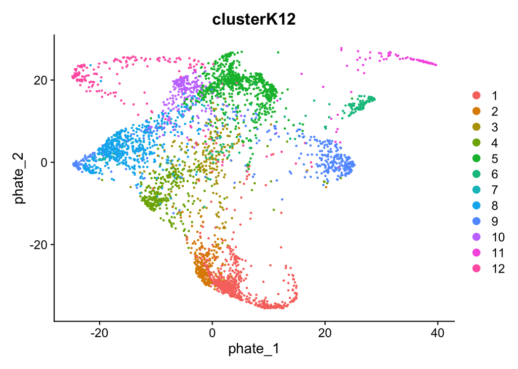

```r
seu[["RNA"]]@data <- TPM
seu[["tsne"]] <- CreateDimReducObject(embeddings = cells.annot[, c("tSNE_1", "tSNE_2")] %>% as.matrix(), assay = DefaultAssay(seu), key = "tSNE_")
seu[["phate"]] <- CreateDimReducObject(embeddings = cells.annot[, c("phate_1", "phate_2")] %>% as.matrix() * 50, assay = DefaultAssay(seu), key = "phate_")
Idents(seu) <- factor(seu$clusterK12)
DimPlot(seu, group.by = "clusterK12", reduction = "phate")
```

# 1. 选择基因集合(特征选择) / Gene Set Selection (Feature Selection)

> 选择不同cluster中的特征基因 / Select characteristic genes from different clusters  
> Using  
> 1) 100 differentially expressed genes per each of 12 subtype clusters and  
> 2) top 100 NMF genes per each of 11 NMF programs

## 1.1 cluster特异表达基因 / Cluster-Specific Expression Genes

> 这里直接采用作者的计算结果 / Here we directly use the author's calculation results

```r
dat <- readxl::read_excel("data/supp/tableS1.xlsx", sheet = "Summary")
head(dat)
```

```
## # A tibble: 6 x 12
##   `Cluster 1` `Cluster 2` `Cluster 3` `Cluster 4` `Cluster 5` `Cluster 6`
##   <chr>       <chr>       <chr>       <chr>       <chr>       <chr>
## 1 Ifi27l2a    Gm13449     Map6        Cd177       Slc4a11     Syt16
## 2 Tgtp1       AC133650.1  Gm43431     Tbc1d24     Il23a       Hbb-bt
## 3 Ly6i        Prmt8       Gm29237     C5ar2       Rrad        Cysrt1
## 4 Tmprss7     Vldlr       Akap5       Ugt1a6b     Tnf         Lrrc26
## 5 Lsmem1      Npr2        Hck         Trpv6       Abtb2       Alpi
## 6 Fosb        AC157822.3  Mrc2        St6galnac3  Lif         Zfp991
## # … with 6 more variables: Cluster 7 <chr>, Cluster 8 <chr>, Cluster 9 <chr>,
## #   Cluster 10 <chr>, Cluster 11 <chr>, Cluster 12 <chr>
```

```r
de.genes <- unlist(head(dat, n=100)) %>% unique()
length(de.genes)
```

```
## [1] 1146
```

## 1.2 NMF中的特征基因 / Feature Genes in NMF

> 这里也直接采用作者的计算结果 / Here we also directly use the author's calculation results

```r
dat <- readxl::read_excel("data/supp/tableS2.xlsx", sheet = "Top weighted NMF topic markers")
head(dat)
```

```
## # A tibble: 6 x 12
##   `Gene Name`    NMF_01    NMF_02    NMF_03    NMF_04   NMF_05   NMF_06   NMF_07
##   <chr>           <dbl>     <dbl>     <dbl>     <dbl>    <dbl>    <dbl>    <dbl>
## 1 Klf6         -1.11e-3  -2.46e-4   0        -1.37e-3  2.70e-3 -1.61e-3 -1.62e-3
## 2 Slc22a18     -3.45e-5  -4.82e-5  -8.05e-5  -8.17e-5  0        0       -7.74e-5
## 3 Igsf5        -2.51e-4  -8.57e-5  -2.66e-4  -2.48e-4 -2.69e-4 -2.69e-4 -1.46e-4
## 4 Scnn1g        7.35e-4   0        -2.74e-4   0        0        0        0
## 5 Tpd52l1       0         0        -6.80e-5  -1.34e-4  0       -2.08e-5  3.20e-4
## 6 Comt         -3.55e-4  -2.39e-4  -3.18e-4  -3.35e-4 -3.58e-4 -3.20e-4 -3.29e-4
## # … with 4 more variables: NMF_08 <dbl>, NMF_09 <dbl>, NMF_10 <dbl>,
## #   NMF_11 <dbl>
```

```r
nmf.genes <- lapply(colnames(dat)[2:ncol(dat)], function(xx) {
  dat %>% arrange(desc(get(xx))) %>% `[[`("Gene Name") %>% head(100)
})

nmf.genes <- unlist(nmf.genes) %>% unique()
length(nmf.genes)
```

```
## [1] 1100
```

```r
comb.genes <- c(de.genes, nmf.genes) %>% unique()
length(comb.genes)
```

```
## [1] 1976
```

# 2. 单细胞转录组离散化 / Single-cell Transcriptome Discretization

> We discretized expression per gene into 10 bins.

分箱算法 / Binning algorithms:  
1) 等长分箱(equal width intervals)  
2) 等频分箱(equal frequency intervals)  
3) 聚类分箱 / Clustering binning  
4) 卡方分箱 / Chi-square binning  
5) 决策树分箱 / Decision tree binning

> 这里尚不清楚作者采用了何种分箱算法，我们默认其采用的是`等长分箱` / It's not clear which binning algorithm the authors used, we assume they used `equal width intervals`

> ```r
> row.idx <- rownames(seu[["RNA"]]@data) %in% comb.genes
> dat <- seu[["RNA"]]@data[row.idx, ] %>% as.matrix()
> dat[1:5, 1:5]
> ```

> ```
> ##         KP_30w_ND_m3_T7_P1_S302 KP_30w_ND_m2_T4_P5_S331 K_12w_ND_m3_T0_P2_S272
> ## Klf6                       7.33                    4.59                   2.15
> ## Brat1                      1.35                    0.00                   0.00
> ## Scnn1g                     0.00                    0.00                   0.00
> ## Tmprss2                    0.00                    2.45                   5.45
> ## Egfl6                      0.00                    4.92                   0.00
> ##         KP_30w_ND_m2_T1_P4_S219 K_2w_ND_m3_T0_P1_S245
> ## Klf6                       5.74                  5.86
> ## Brat1                      0.00                  4.70
> ## Scnn1g                     0.00                  0.00
> ## Tmprss2                    0.00                  0.00
> ## Egfl6                      2.32                  4.87
> ```

> ```r
> disc.expr <- apply(dat, 2, function(xx) {
>   infotheo::discretize(xx, disc = "equalwidth", 10) %>% unlist()
> })
>
> rownames(disc.expr) <- rownames(dat)
> dat[1:5,1:5]
> ```

> ```
> ##         KP_30w_ND_m3_T7_P1_S302 KP_30w_ND_m2_T4_P5_S331 K_12w_ND_m3_T0_P2_S272
> ## Klf6                       7.33                    4.59                   2.15
> ## Brat1                      1.35                    0.00                   0.00
> ## Scnn1g                     0.00                    0.00                   0.00
> ## Tmprss2                    0.00                    2.45                   5.45
> ## Egfl6                      0.00                    4.92                   0.00
> ##         KP_30w_ND_m2_T1_P4_S219 K_2w_ND_m3_T0_P1_S245
> ## Klf6                       5.74                  5.86
> ## Brat1                      0.00                  4.70
> ## Scnn1g                     0.00                  0.00
> ## Tmprss2                    0.00                  0.00
> ## Egfl6                      2.32                  4.87
> ```

> ```r
> disc.expr[1:5,1:5]
> ```

> ```
> ##         KP_30w_ND_m3_T7_P1_S302 KP_30w_ND_m2_T4_P5_S331 K_12w_ND_m3_T0_P2_S272
> ## Klf6                          5                       4                      2
> ## Brat1                         1                       1                      1
> ## Scnn1g                        1                       1                      1
> ## Tmprss2                       1                       2                      4
> ## Egfl6                         1                       4                      1
> ##         KP_30w_ND_m2_T1_P4_S219 K_2w_ND_m3_T0_P1_S245
> ## Klf6                          4                     4
> ## Brat1                         1                     4
> ## Scnn1g                        1                     1
> ## Tmprss2                       1                     1
> ## Egfl6                         2                     4
> ```

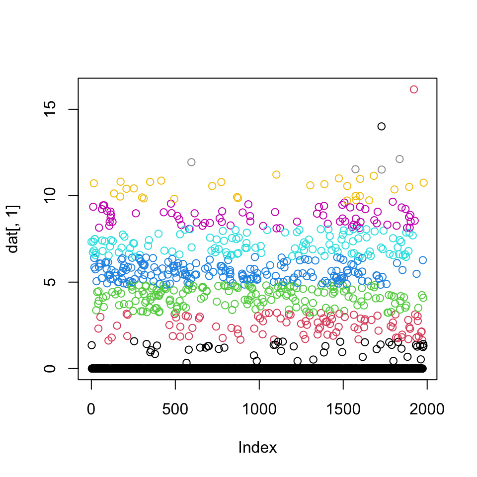

> ```r
> # 查看分箱结果 View the binning results
> plot(dat[,1], col=disc.expr[,1])
> ```